# Configuração e utilização do RStudio e Shiny Server na AWS

Thiago Pires | FGV

20 de agosto, 2018

# Computação em nuvem

## Computação em nuvem

> *É o fornecimento de serviços de computação – servidores, armazenamento, bancos de dados, rede, software, análise e muito mais – pela Internet (“a nuvem”).*

## Alguns dos benefícios

- Redução de custos
- Fácil manutenção
- Acessibilidade e facibilidade de colaboração
- Escalabilidade
- Segurança

Fonte: *[10 motivos para aderir à nuvem e dar adeus ao servidor](https://www.penso.com.br/top-10-motivos-para-aderir-a-nuvem/)*

# AWS

## Amazon Web Services

[figure not shown]

A [Amazon Web Services](https://aws.amazon.com/pt/) (AWS) é uma plataforma de serviços em nuvem segura, oferecendo **poder computacional**, **armazenamento** de banco de dados, distribuição de conteúdo e outras funcionalidades.

## Abrir uma conta

#### Opção gratuíta para 12 meses

- Nível gratuíto: https://aws.amazon.com/pt/free/
- Siga as instruções online para abertura de conta.
- Parte do procedimento de cadastro envolve uma chamada telefônica e a digitação de um **PIN** usando o teclado do telefone.

## Amazon EC2

[figure not shown]

# Configuração da máquina

## Escolher uma máquina

[figure not shown]

## Escolher o tipo de máquina

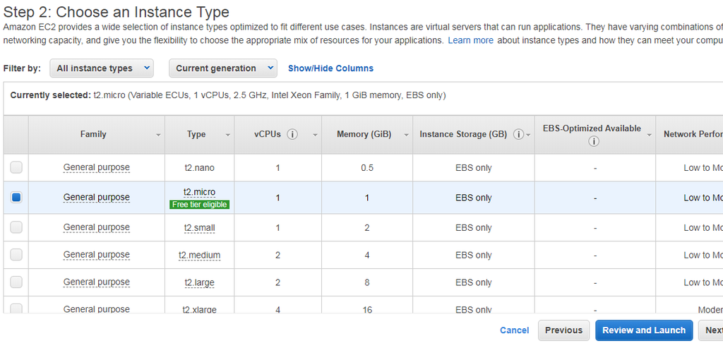

## Detalhes na configuração

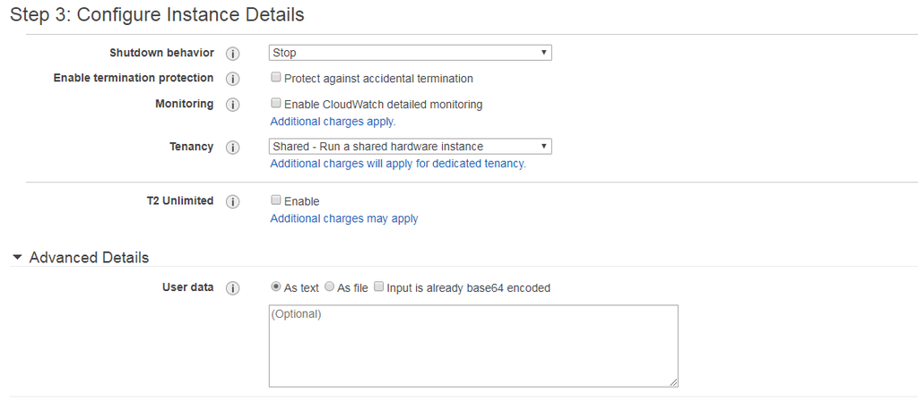

## Detalhes avançados

```
#!/bin/bash

#install R
sudo amazon-linux-extras install R3.4

#install RStudio-Server (2018-07-19)
sudo wget https://download2.rstudio.org/rstudio-server-rhel-1.1.456-x86_64.rpm
sudo yum install -y --nogpgcheck rstudio-server-rhel-1.1.456-x86_64.rpm
sudo rm rstudio-server-rhel-1.1.456-x86_64.rpm

#install Shiny and Shiny-Server (2018-07-19)
sudo -i R -e "install.packages(c('shiny', 'rmarkdown', 'plumber'), repos = 'https://cran.fiocruz.br/')"
sudo wget https://download3.rstudio.org/centos6.3/x86_64/shiny-server-1.5.7.907-rh6-x86_64.rpm
sudo yum install -y --nogpgcheck shiny-server-1.5.7.907-rh6-x86_64.rpm
sudo rm shiny-server-1.5.7.907-rh6-x86_64.rpm

#add user(s)
useradd usuário
echo usuário:senha | chpasswd

#permission to folder
sudo chmod 777 /srv/shiny-server
```

## Detalhes avançados (Ubuntu)

```
#install R
sudo apt-get update
sudo apt-get upgrade
sudo apt-get install r-base-core r-base-dev libcurl4-openssl-dev libssl-dev libxml2-dev

#updated R
sudo add-apt-repository "deb http://cran.rstudio.com/bin/linux/ubuntu $(lsb_release -sc)/"
sudo apt-key adv --keyserver keyserver.ubuntu.com --recv-keys E084DAB9
sudo add-apt-repository ppa:marutter/rdev
sudo apt-get update
sudo apt-get upgrade
sudo apt-get install r-base

#install Shiny and Shiny-Server (2018-07-19)
sudo -i R -e "install.packages(c('shiny', 'rmarkdown', 'plumber', 'gtrendsR', 'dplyr', 'flexdashboard', 'xts', 'dygraphs', 'tbl2xts', 'aws.s3'), repos = 'https://cran.fiocruz.br/')"
wget https://download3.rstudio.org/ubuntu-14.04/x86_64/shiny-server-1.5.7.907-amd64.deb
sudo dpkg -i shiny-server-1.5.7.907-amd64.deb
sudo rm shiny-server-1.5.7.907-amd64.deb

#permission to folder
sudo chmod 777 /srv/shiny-server
```

OBS: Este script não está automático como o anterior. Os comandos deverão ser inseridos depois de ser iniciada a máquina na nuvem.

## Armazenamento

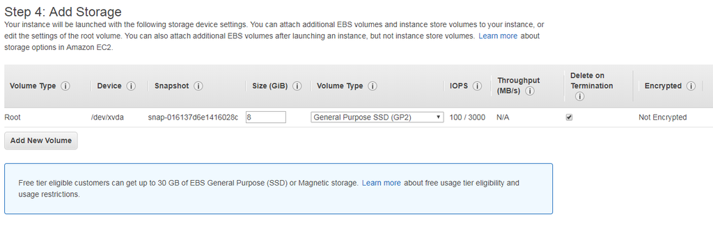

## Controle de tráfego na máquina

#### Portas de acesso

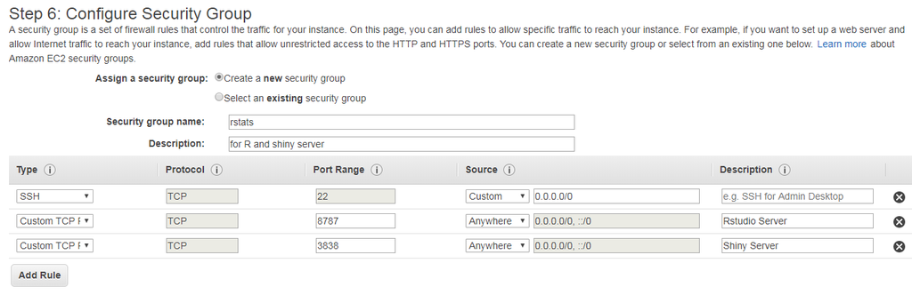

## Criação de uma chave para conexão segura

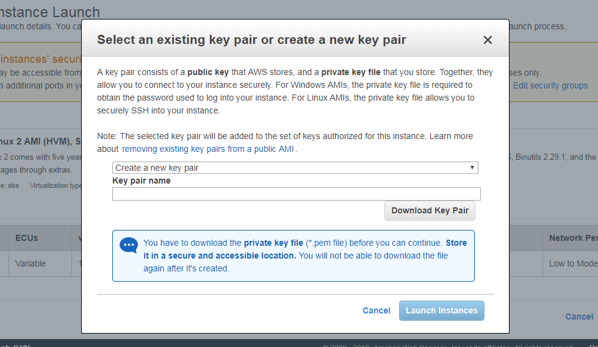

## Máquina funcionando

**Em Public DNS (IPv4)** está o endereço de acesso à máquina. O usuário é o **ec2-user**.

[figure not shown]

## Acessando à máquina através do **git-bash**

```
ssh ec2-user@ec2-34-219-66-250.us-west-2.compute.amazonaws.com -i thop.pem
```

[figure not shown]

[figure not shown]

## Informações e controle da máquina pelo celular

[figure not shown]

[figure not shown]

# R, RStudio Server e Shiny Server

## RStudio e Shiny Server

- Para acessar o RStudio Server no browser:

```
http://ec2-54-202-207-158.us-west-2.compute.amazonaws.com:8787
```

- Para acessar o Shiny Server:

```
http://ec2-54-202-207-158.us-west-2.compute.amazonaws.com:3838
```

- Para acessar uma aplicação específica:

```
http://ec2-54-202-207-158.us-west-2.compute.amazonaws.com:3838/sample-apps/hello/
```

# Plumber

## Configurações necessárias

- Verificar as portas em funcionamento na máquina:

```
netstat -ant
```

- Colocar a porta de acesso à API: `:8000`

## Criando uma API

Arquivo plumber.R

```r
#' Return the sum of two numbers
#' @param a The first number to add
#' @param b The second number to add
#' @get /sum
#' @html
function(a, b){
  paste("<html><h1>=", as.numeric(a) + as.numeric(b), "<html><h1>")
}
```

Baixar arquivo **plumber.R** na máquina

```
wget https://gist.githubusercontent.com/th1460/5651ece3822f958c018150db6506b1f4/raw/e47b27570a2a04c74192d177f500d3040db05d75/plumber.R
```

Inicializar a API no terminal

```
R -e 'pr <- plumber::plumb("plumber.R"); pr$run(host = "0.0.0.0", port = 8000)'
```

## Acessando a API

Digitando no browser o **host** a **porta** e os **argumentos** de acesso à API:

```
http://ec2-54-200-63-187.us-west-2.compute.amazonaws.com:8000/sum?a=145&b=189
```

[figure not shown]

# Amazon S3

## Armazenamento de objetos

[figure not shown]

## Autorizações para clientes

Para dar acessos específicos. É necessária esta etapa para criar o id e senha de acessos para utlizar o AWS CLI.

[figure not shown]

## Instalando cliente e configurando

```
sudo apt-get install awscli

aws configure

sudo aws s3 cp s3://th1460/shiny_dengue.Rmd /srv/shiny-server/sample-apps/gtrendsR/shiny_dengue.Rmd
```

## library(aws.s3)

```r
require(aws.s3)

Sys.setenv("AWS_ACCESS_KEY_ID" = "AKIAJINKOTYFNMTNTRLQ",
           "AWS_SECRET_ACCESS_KEY" = "hsxs3k1ayEr7ruRTLge6HQukpKolJxSGorCTJcOv")

# lista de buckets
bucketlist()

# upload dados no S3
s3saveRDS(x = dados, bucket = "th1460", object = "dados.rds")

# ler dados do S3
s3readRDS(object = "dados.rds", bucket = "th1460")

# deletar dados
delete_object(object = "dados.rds", bucket = "th1460")
```

# Aplicação

th1460.github.io